# Seurat tutorial on public data

[LabEx CORTEX Bioinformatics Platform](https://labex-cortex.universite-lyon.fr/) - Lyon 1 University - vignette produced by Emeric Texeraud

2021-09-10

## Load packages

```r
library(tidyverse, quietly = TRUE)
library(Seurat, quietly = TRUE)
library(patchwork)
library(scater)
```

# 1. Overview of all cells

## Setup the Seurat Object

```r
# Load  the public dataset
seurat_matrix <- Read10X('/mnt/Data1/public_vignettes/cellranger_output/neuron_1k/outs/filtered_feature_bc_matrix')
seur <- CreateSeuratObject(counts = seurat_matrix, project = "neuron_1k", min.cells = 3, min.features = 100)
seur
```

```
An object of class Seurat
16237 features across 1280 samples within 1 assay
Active assay: RNA (16237 features, 0 variable features)
```

## QC and sctransform

### QC

QC metrics

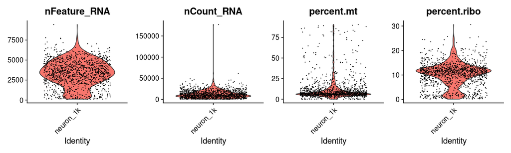

```r
# QC metrics calculation and visualization
seur$percent.mt <- PercentageFeatureSet(seur, pattern = "^mt-")
seur$percent.ribo <- PercentageFeatureSet(seur, pattern = "^Rp[sl][[:digit:]]")
VlnPlot(seur, features = c("nFeature_RNA", "nCount_RNA", "percent.mt", "percent.ribo"), ncol = 4, pt.size = 0.1)
```

Distribution of the data

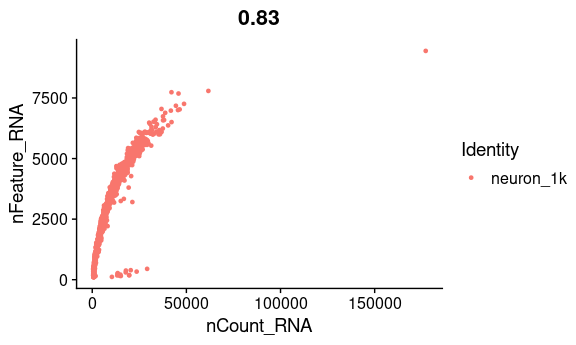

```r
FeatureScatter(seur, feature1 = "nCount_RNA", feature2 = "nFeature_RNA")
```

We remove cells that makes nCount_RNA plot unreadable, and cells which have too much mitochondrial genes.

```r
seur = subset(seur, subset = (percent.mt < 20 & nCount_RNA < 50000))
```

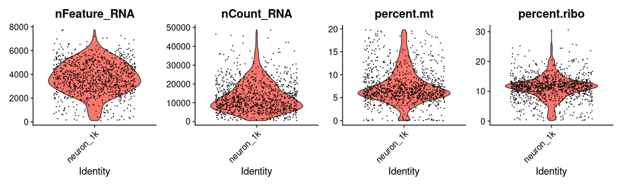

```r
VlnPlot(seur, features = c("nFeature_RNA", "nCount_RNA", "percent.mt", "percent.ribo"), ncol = 4, pt.size = 0.1)
```

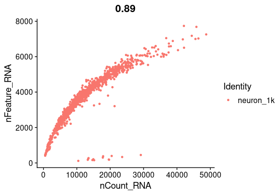

```r
FeatureScatter(seur, feature1 = "nCount_RNA", feature2 = "nFeature_RNA", group.by = "orig.ident")
```

We still have cells having too much counts, we will removes them, as well as the cells having too few features, which cannot be true cells.

```r
seur = subset(seur, subset = (nFeature_RNA > 1000 & nCount_RNA < 30000))
```

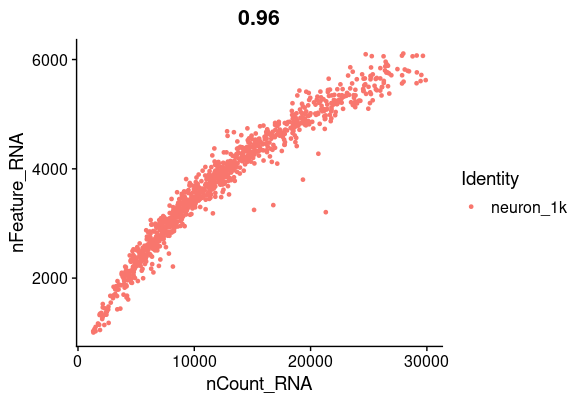

```r
FeatureScatter(seur, feature1 = "nCount_RNA", feature2 = "nFeature_RNA", group.by = "orig.ident")
```

Now we have very few cells far from the gradient, which is a good thing, as nFeature_RNA and nCount_RNA should be proportional.

### sctransform normalization

The latest version of sctransform also supports using glmGamPoi package which substantially improves the speed of the learning procedure. It can be invoked by specifying method=“glmGamPoi”. This single command replaces NormalizeData(), ScaleData(), and FindVariableFeatures().

```r
seur <- SCTransform(seur, method = "glmGamPoi", verbose = FALSE)
```

### linear dimensional reduction and the ‘dimensionality’ of the dataset

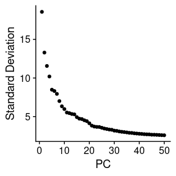

```r
seur <- RunPCA(seur, verbose = FALSE)
ElbowPlot(seur, ndims = 50)
```

Here we take a number of PC around the elbow, where the curve flattens, it is a sufficient number of PC to explain most of the deviation. Here it is around 10 PCs.

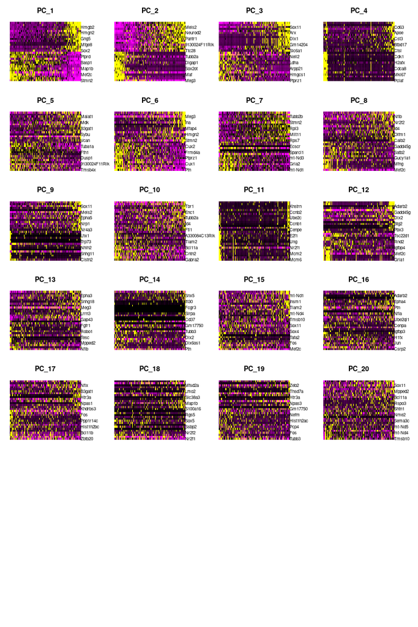

```r
DimHeatmap(seur, dims = 1:20, assays = "SCT", ncol = 4)
```

The majority of true signal is captured in the first 12 PCs, so we will use 12 PCs to analyse data. After 12 PCs, most of the yellow and purple signals are mixed, and thus the superior PCs don’t explain a lot of variance.

### Non-linear dimensional reduction (UMAP)

```r
#Cluster the cells
DefaultAssay(seur) <- "SCT"
seur <- FindNeighbors(seur, dims = 1:12, verbose = FALSE)
```

```r
seur <- FindClusters(seur, resolution = 0.5, verbose = FALSE)
#Reduction
seur <- RunUMAP(seur, dims = 1:12, verbose = FALSE)
```

[output not shown]

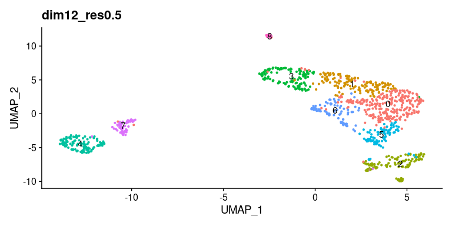

```r
DimPlot(seur, label = TRUE, pt.size = 0.8) + NoLegend() + ggtitle("dim12_res0.5")
```

We have 9 clusters in the dataset.

### Individual cluster metrics on res0.5 for hi resolution

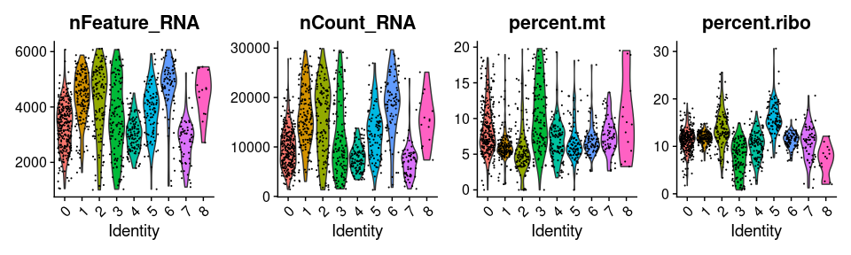

```r
VlnPlot(seur, features = c("nFeature_RNA", "nCount_RNA", "percent.mt", "percent.ribo"), ncol = 4,
        group.by = "seurat_clusters", pt.size = 0.1)
```

None of the clusters seems to have a significantly bad quality

### Identification of cluster biomarkers

```r
markers.dim12 <-FindAllMarkers(seur, logfc.threshold = 1, min.pct = 0.5, verbose = FALSE, assay = "RNA", only.pos = TRUE)
```

```r
top10.markers.dim12 = markers.dim12 %>% mutate(diff.pct = (pct.1 - pct.2)) %>% group_by(cluster) %>%
  slice_max(order_by = avg_log2FC, n = 20) %>% slice_min(order_by = p_val_adj, n = 10)
top10.markers.dim12
```

| p_val | avg_log2FC | pct.1 | pct.2 | p_val_adj | cluster | gene | diff.pct |
| --- | --- | --- | --- | --- | --- | --- | --- |
| 7.952146e-38 | 3.630911 | 0.632 | 0.216 | 1.291190e-33 | 0 | Unc5d | 0.416 |
| 6.299293e-36 | 6.982475 | 0.502 | 0.138 | 1.022816e-31 | 0 | Lratd1 | 0.364 |
| 2.004897e-29 | 5.892957 | 0.907 | 0.565 | 3.255351e-25 | 0 | Pou3f2 | 0.342 |
| 1.355660e-26 | 8.136993 | 0.888 | 0.572 | 2.201185e-22 | 0 | Frmd4b | 0.316 |
| 3.569835e-26 | 20.059585 | 0.974 | 0.862 | 5.796341e-22 | 0 | Gria2 | 0.112 |
| 8.858267e-26 | 2.115187 | 0.539 | 0.220 | 1.438317e-21 | 0 | Prex1 | 0.319 |
| 9.225685e-20 | 12.165124 | 0.959 | 0.912 | 1.497974e-15 | 0 | Mir100hg | 0.047 |
| 1.436522e-19 | 3.298137 | 0.914 | 0.706 | 2.332481e-15 | 0 | Cttnbp2 | 0.208 |
| 3.986359e-15 | 6.793854 | 0.558 | 0.302 | 6.472652e-11 | 0 | Rnd2 | 0.256 |
| 2.317547e-12 | 6.203353 | 0.803 | 0.638 | 3.763001e-08 | 0 | Plxna2 | 0.165 |

[output cut: 80 more lines]

### Visualization of marker expression

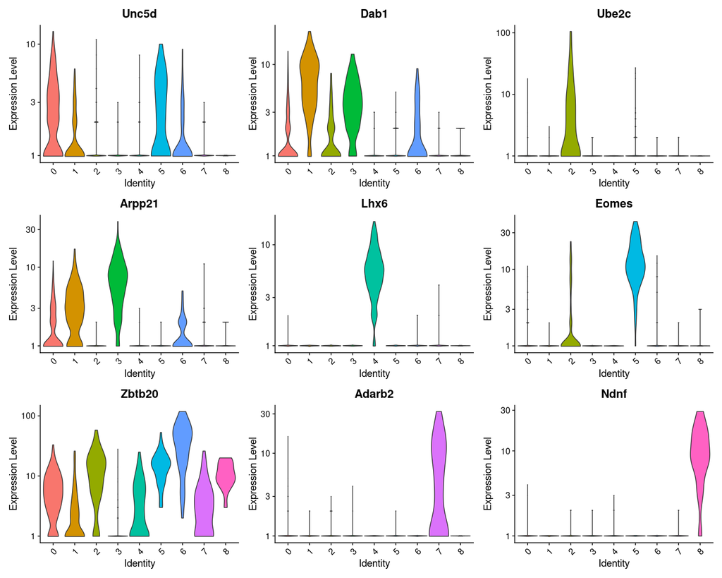

```r
VlnPlot(seur, features = c("Unc5d", "Dab1", "Ube2c", "Arpp21", "Lhx6", "Eomes",
                          "Zbtb20", "Adarb2", "Ndnf"), ncol = 3, pt.size = 0, assay = "RNA", log = TRUE)
```

We use the top 10 markers for each clusters to infer their identity.